# TimeSeries

Student Name : Kabita Paul

25/10/2019

**Purpose:**

To perform time series analysis to predict future customer sentiment on Twitter Description: The objective of this study is to find the right time series model to make predictions about the future customer sentiment in Twitter network of AT&T. The data contains the average hourly sentiment of tweets customers sent to AT&T’s Twitter handle.

**Instructions:** Please follow these steps: 1. In Canvas, navigate to Assignments and then Assignment4 2. Download and save the data set ATT_Twitter.csv 3. Read the file:

```r
library(data.table)
data <- fread("ATT_Twitter.csv", sep=",", header=T, strip.white = T, na.strings = c("NA","NaN","","?"))
```

```r
#colnames(data)
head(data)
```

```
##                   time         x
## 1: 2016-06-16 00:00:00 0.4812879
## 2: 2016-06-16 01:00:00 0.4351754
## 3: 2016-06-16 02:00:00 0.4652584
## 4: 2016-06-16 03:00:00 0.4488735
## 5: 2016-06-16 04:00:00 0.5142909
## 6: 2016-06-16 05:00:00 0.4703483
```

```r
#tail(data)
```

4. Use packages “forecast”, “timeSeries”, and “rugarch” to answer the following questions:

```r
library(forecast)
library(timeSeries)
library(rugarch)
```

4.1. (5 points) Paste the plot of the time series in the space below:

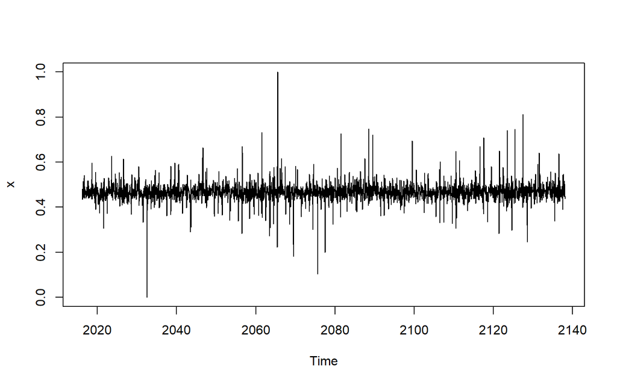

```r
x = ts(data[,2],start= c(2016,6,16,0), frequency= 24)
# x
plot(x)
```

```r
#x
```

4.2. (10 points) Determine if this time series is a random walk process?

```r
PP.test(x) # Phillips-Perron Unit Root Test to check if the time series is random walk process
```

```
##
##  Phillips-Perron Unit Root Test
##
## data:  x
## Dickey-Fuller = -51.212, Truncation lag parameter = 9, p-value =
## 0.01
```

p value 0.01 suggests rejection of null hypothesis. Therefore, the time series is not random walk.

4.3. (20 points) Use ACF and PACF to determine if the times series has any MA or AR process. If so, what is (are) the order(s)? Please paste the ACF and PACF plots in the space below:

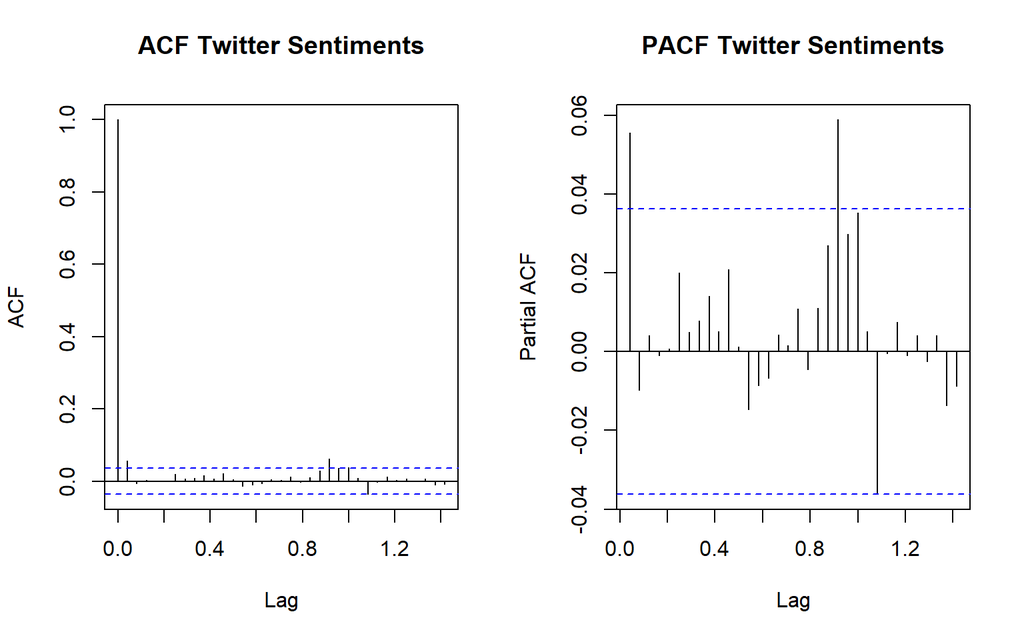

```r
par(mfrow = c(1,2))
acf(x,main='ACF Twitter Sentiments')
pacf(x,main='PACF Twitter Sentiments')
```

4.4. (5 points) Use auto.arima function to determine the best model ARIMA model for this data. What is the best order?

```r
ARIMAfit = auto.arima(x, approximation=FALSE,trace=TRUE)
```

```
##
##  ARIMA(2,0,2)(1,0,1)[24] with non-zero mean : -10084.44
##  ARIMA(0,0,0)            with non-zero mean : -10082.79
##  ARIMA(1,0,0)(1,0,0)[24] with non-zero mean : -10091.39
##  ARIMA(0,0,1)(0,0,1)[24] with non-zero mean : -10091.46
##  ARIMA(0,0,0)            with zero mean     : 3886.265
##  ARIMA(0,0,1)            with non-zero mean : -10089.99
##  ARIMA(0,0,1)(1,0,1)[24] with non-zero mean : -10090.33
##  ARIMA(0,0,1)(0,0,2)[24] with non-zero mean : -10089.99
##  ARIMA(0,0,1)(1,0,0)[24] with non-zero mean : -10091.55
##  ARIMA(0,0,1)(2,0,0)[24] with non-zero mean : -10089.98
##  ARIMA(0,0,1)(2,0,1)[24] with non-zero mean : -10088.86
##  ARIMA(0,0,0)(1,0,0)[24] with non-zero mean : -10084.8
##  ARIMA(1,0,1)(1,0,0)[24] with non-zero mean : -10089.74
##  ARIMA(0,0,2)(1,0,0)[24] with non-zero mean : -10089.73
##  ARIMA(1,0,2)(1,0,0)[24] with non-zero mean : -10087.73
##  ARIMA(0,0,1)(1,0,0)[24] with zero mean     : Inf
##
##  Best model: ARIMA(0,0,1)(1,0,0)[24] with non-zero mean
```

```r
summary(ARIMAfit)
```

```
## Series: x
## ARIMA(0,0,1)(1,0,0)[24] with non-zero mean
##
## Coefficients:
##          ma1    sar1    mean
##       0.0552  0.0349  0.4677
## s.e.  0.0186  0.0185  0.0009
##
## sigma^2 estimated as 0.001862:  log likelihood=5049.78
## AIC=-10091.57   AICc=-10091.55   BIC=-10067.64
##
## Training set error measures:
##                        ME      RMSE        MAE  MPE MAPE      MASE
## Training set 5.595611e-06 0.0431274 0.02641976 -Inf  Inf 0.6811662
##                       ACF1
## Training set -0.0004132474
```

Then we can use the best ARIMA model to forecastfuture customersentiment

```r
pred = predict(ARIMAfit, n.ahead = 48)
pred
```

```
## $pred
## Time Series:
## Start = c(2138, 6)
## End = c(2140, 5)
## Frequency = 24
##  [1] 0.4661776 0.4674742 0.4676262 0.4686064 0.4674924 0.4667507 0.4672339
##  [8] 0.4680632 0.4650049 0.4671258 0.4703189 0.4671523 0.4678355 0.4704718
## [15] 0.4683125 0.4673131 0.4670010 0.4674511 0.4694056 0.4670060 0.4688994
## [22] 0.4684870 0.4671194 0.4667072 0.4676564 0.4677016 0.4677070 0.4677412
## [29] 0.4677023 0.4676764 0.4676933 0.4677222 0.4676154 0.4676895 0.4678010
## [36] 0.4676904 0.4677143 0.4678063 0.4677309 0.4676960 0.4676851 0.4677008
## [43] 0.4677691 0.4676853 0.4677514 0.4677370 0.4676893 0.4676749
##
## $se
## Time Series:
## Start = c(2138, 6)
## End = c(2140, 5)
## Frequency = 24
##  [1] 0.04314951 0.04321517 0.04321517 0.04321517 0.04321517 0.04321517
##  [7] 0.04321517 0.04321517 0.04321517 0.04321517 0.04321517 0.04321517
## [13] 0.04321517 0.04321517 0.04321517 0.04321517 0.04321517 0.04321517
## [19] 0.04321517 0.04321517 0.04321517 0.04321517 0.04321517 0.04321517
## [25] 0.04324141 0.04324149 0.04324149 0.04324149 0.04324149 0.04324149
## [31] 0.04324149 0.04324149 0.04324149 0.04324149 0.04324149 0.04324149
## [37] 0.04324149 0.04324149 0.04324149 0.04324149 0.04324149 0.04324149
## [43] 0.04324149 0.04324149 0.04324149 0.04324149 0.04324149 0.04324149
```

```r
#pred$pred[1-24]
pred$se[1-24]
```

```
##  [1] 0.04314951 0.04321517 0.04321517 0.04321517 0.04321517 0.04321517
##  [7] 0.04321517 0.04321517 0.04321517 0.04321517 0.04321517 0.04321517
## [13] 0.04321517 0.04321517 0.04321517 0.04321517 0.04321517 0.04321517
## [19] 0.04321517 0.04321517 0.04321517 0.04321517 0.04321517 0.04324141
## [25] 0.04324149 0.04324149 0.04324149 0.04324149 0.04324149 0.04324149
## [31] 0.04324149 0.04324149 0.04324149 0.04324149 0.04324149 0.04324149
## [37] 0.04324149 0.04324149 0.04324149 0.04324149 0.04324149 0.04324149
## [43] 0.04324149 0.04324149 0.04324149 0.04324149 0.04324149
```

We can plot the data

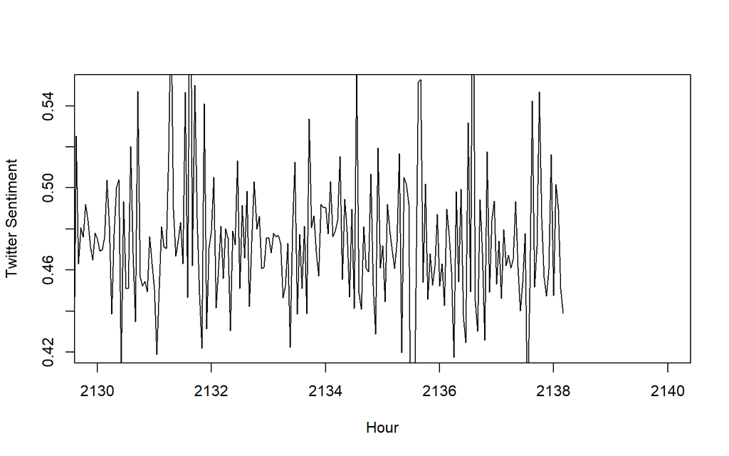

```r
par(mfrow = c(1,1))
plot(x,type='l',xlim=c(2130,2140),ylim=c(.42,.55),xlab = 'Hour',ylab = 'Twitter Sentiment')
lines(10^(pred$pred[1-24]),col='blue')
lines(10^(pred$pred[1-24]+2*pred$se[1-24]),col='orange')
lines(10^(pred$pred[1-24]-2*pred$se[1-24]),col='orange')
```

5. Use “rugarch” package to build ARCH and GARCH models. Use “sGARCH” in the specification. 5.1. (5 points) First use armaOrder(0,0). What are the values of AIC and BIC?

```r
#loading packages
library(quantmod)
library(lattice)
library(timeSeries)
library(rugarch)
```

```r
spec1= ugarchspec(variance.model=list(model="sGARCH"),
                 mean.model=list(armaOrder=c(0,0)))
```

```r
fit1=ugarchfit(data=x,spec=spec1)
show(fit1)
```

```
##
## *---------------------------------*
## *          GARCH Model Fit        *
## *---------------------------------*
##
## Conditional Variance Dynamics
## -----------------------------------
## GARCH Model  : sGARCH(1,1)
## Mean Model   : ARFIMA(0,0,0)
## Distribution : norm
##
## Optimal Parameters
## ------------------------------------
##         Estimate  Std. Error  t value Pr(>|t|)
## mu      0.467837    0.000794  589.102        0
## omega   0.000016    0.000000   42.805        0
## alpha1  0.003270    0.000193   16.978        0
## beta1   0.988343    0.000396 2494.667        0
##
## Robust Standard Errors:
##         Estimate  Std. Error   t value Pr(>|t|)
## mu      0.467837    0.000837  558.7647        0
## omega   0.000016    0.000001   13.1954        0
## alpha1  0.003270    0.000339    9.6388        0
## beta1   0.988343    0.000492 2009.4091        0
##
## LogLikelihood : 5050.903
##
## Information Criteria
## ------------------------------------
##
## Akaike       -3.4473
## Bayes        -3.4392
## Shibata      -3.4473
## Hannan-Quinn -3.4444
##
## Weighted Ljung-Box Test on Standardized Residuals
## ------------------------------------
##                         statistic  p-value
## Lag[1]                      7.612 0.005798
```

[output cut: 37 more lines]

```
## Negative Sign Bias  4.2691 2.025e-05 ***
## Positive Sign Bias  2.3126 2.081e-02  **
## Joint Effect       26.1848 8.724e-06 ***
##
##
## Adjusted Pearson Goodness-of-Fit Test:
## ------------------------------------
##   group statistic p-value(g-1)
## 1    20     694.2   6.008e-135
## 2    30     791.8   6.065e-148
## 3    40     786.6   5.949e-140
## 4    50     835.5   1.255e-143
##
##
## Elapsed time : 0.6355741
```

Then we obtain fitted volatility series:

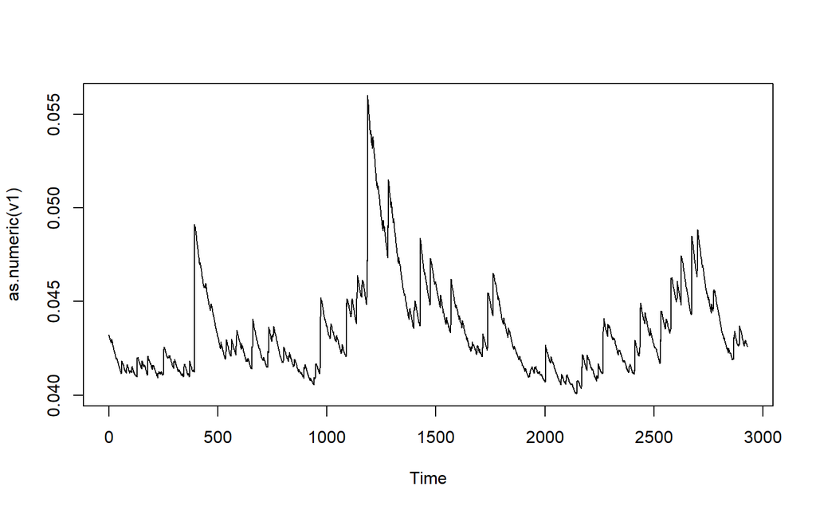

```r
v1=sigma(fit1)
ts.plot(as.numeric(v1))
```

```r
fit1_pred <- ugarchforecast(fit1, data = x, n.ahead = 10)
head(sigma(fit1_pred))
```

```
##     1978-01-06 19:00:00
## T+1          0.04256819
## T+2          0.04257717
## T+3          0.04258608
## T+4          0.04259490
## T+5          0.04260365
## T+6          0.04261233
```

```r
head(fitted(fit1_pred))
```

```
##     1978-01-06 19:00:00
## T+1           0.4678372
## T+2           0.4678372
## T+3           0.4678372
## T+4           0.4678372
## T+5           0.4678372
## T+6           0.4678372
```

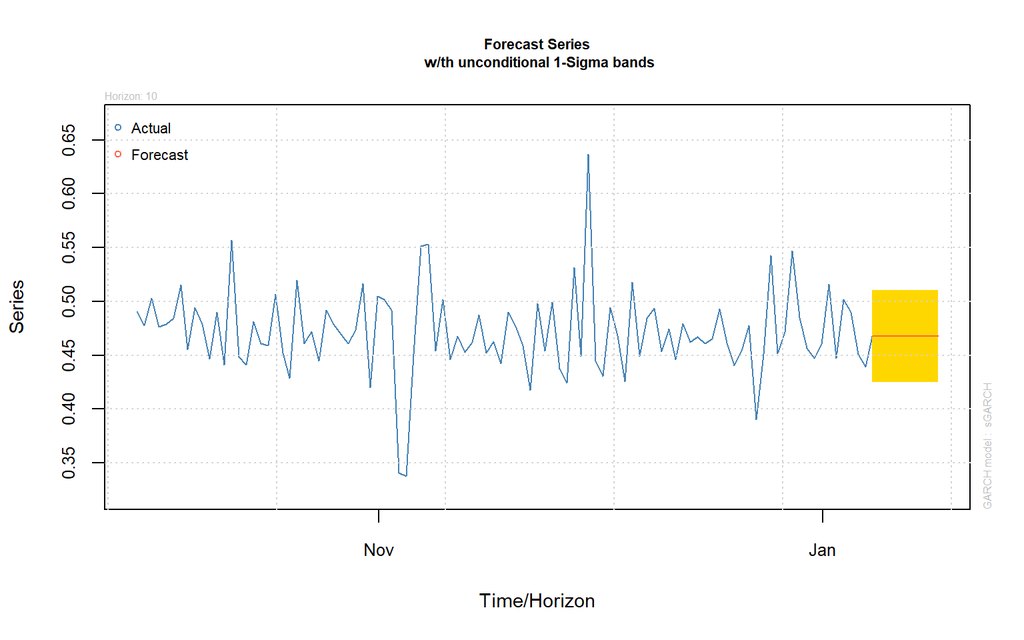

```r
plot(fit1_pred,which=1)
```

5.2. (5 points) Now use armaOrder(0,1). What are the values of AIC and BIC?

We can now specify a ARMA(0,1) model with mean-equation being a constant:

```r
spec2=ugarchspec(variance.model=list(model="sGARCH"),
                 mean.model=list(armaOrder=c(0,1)))
fit2=ugarchfit(data=x,spec=spec2)
show(fit2)
```

```
##
## *---------------------------------*
## *          GARCH Model Fit        *
## *---------------------------------*
##
## Conditional Variance Dynamics
## -----------------------------------
## GARCH Model  : sGARCH(1,1)
## Mean Model   : ARFIMA(0,0,1)
## Distribution : norm
##
## Optimal Parameters
## ------------------------------------
##         Estimate  Std. Error    t value Pr(>|t|)
## mu      0.467711    0.000840  556.61548 0.000000
## ma1     0.056630    0.018587    3.04672 0.002314
## omega   0.000002    0.000000  150.30913 0.000000
## alpha1  0.000008    0.000030    0.26594 0.790289
## beta1   0.998880    0.000129 7756.37687 0.000000
##
## Robust Standard Errors:
##         Estimate  Std. Error    t value Pr(>|t|)
## mu      0.467711    0.001001 467.099974 0.000000
## ma1     0.056630    0.022645   2.500784 0.012392
## omega   0.000002    0.000000  17.111764 0.000000
## alpha1  0.000008    0.000254   0.031453 0.974908
## beta1   0.998880    0.001056 945.704841 0.000000
##
## LogLikelihood : 5048.557
##
## Information Criteria
## ------------------------------------
##
## Akaike       -3.4451
## Bayes        -3.4348
## Shibata      -3.4451
## Hannan-Quinn -3.4414
##
## Weighted Ljung-Box Test on Standardized Residuals
## ------------------------------------
```

[output cut: 40 more lines]

```
## Negative Sign Bias  4.1483 3.445e-05 ***
## Positive Sign Bias  2.5299 1.146e-02  **
## Joint Effect       25.6796 1.113e-05 ***
##
##
## Adjusted Pearson Goodness-of-Fit Test:
## ------------------------------------
##   group statistic p-value(g-1)
## 1    20     715.7   1.700e-139
## 2    30     749.2   5.236e-139
## 3    40     762.8   5.030e-135
## 4    50     792.7   6.951e-135
##
##
## Elapsed time : 0.6219971
```

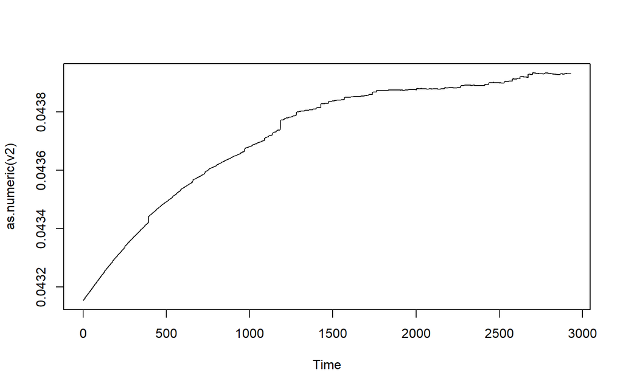

```r
v2=sigma(fit2)
ts.plot(as.numeric(v2))
```

```r
fit2_pred <- ugarchforecast(fit2, data = x, n.ahead = 10)
head(sigma(fit2_pred))
```

```
##     1978-01-06 19:00:00
## T+1          0.04393086
## T+2          0.04393090
## T+3          0.04393094
## T+4          0.04393098
## T+5          0.04393102
## T+6          0.04393105
```

```r
head(fitted(fit2_pred))
```

```
##     1978-01-06 19:00:00
## T+1           0.4661424
## T+2           0.4677109
## T+3           0.4677109
## T+4           0.4677109
## T+5           0.4677109
## T+6           0.4677109
```

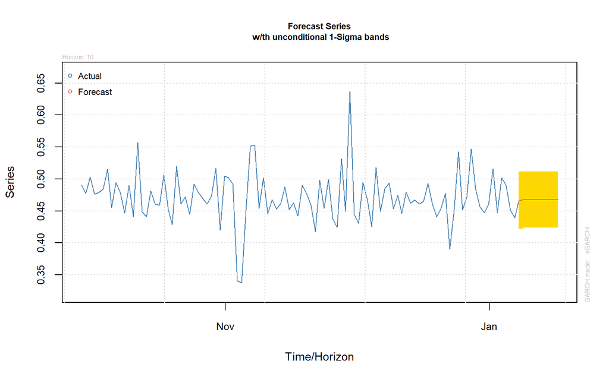

```r
plot(fit2_pred,which=1)
```

6. Use “rugarch” package to build ARCH and GARCH models. Use “apARCH” in the specification. 6.1. (5 points) First use armaOrder(0,0). What are the values of AIC and BIC?

```r
spec3=ugarchspec(variance.model=list(model="apARCH"),
                 mean.model=list(armaOrder=c(0,0)))
fit3=ugarchfit(data=x,spec=spec3)
show(fit3)
```

```
##
## *---------------------------------*
## *          GARCH Model Fit        *
## *---------------------------------*
##
## Conditional Variance Dynamics
## -----------------------------------
## GARCH Model  : apARCH(1,1)
## Mean Model   : ARFIMA(0,0,0)
## Distribution : norm
##
## Optimal Parameters
## ------------------------------------
##         Estimate  Std. Error  t value Pr(>|t|)
## mu      0.468271    0.000557 840.3751  0.00000
## omega   0.017385    0.004691   3.7063  0.00021
## alpha1  0.391515    0.029007  13.4973  0.00000
## beta1   0.474250    0.028254  16.7854  0.00000
## gamma1  0.405980    0.047251   8.5920  0.00000
## delta   0.860630    0.087351   9.8526  0.00000
##
## Robust Standard Errors:
##         Estimate  Std. Error  t value Pr(>|t|)
## mu      0.468271    0.000857 546.2964 0.000000
## omega   0.017385    0.017637   0.9857 0.324279
## alpha1  0.391515    0.089789   4.3604 0.000013
## beta1   0.474250    0.068084   6.9657 0.000000
## gamma1  0.405980    0.093670   4.3342 0.000015
## delta   0.860630    0.329882   2.6089 0.009083
##
## LogLikelihood : 5364.358
##
## Information Criteria
## ------------------------------------
##
## Akaike       -3.6601
## Bayes        -3.6478
## Shibata      -3.6601
## Hannan-Quinn -3.6557
##
```

[output cut: 43 more lines]

```
## Negative Sign Bias  1.0553 0.2914
## Positive Sign Bias  0.1710 0.8642
## Joint Effect        1.1516 0.7646
##
##
## Adjusted Pearson Goodness-of-Fit Test:
## ------------------------------------
##   group statistic p-value(g-1)
## 1    20     384.4    7.531e-70
## 2    30     386.9    3.269e-64
## 3    40     422.0    9.004e-66
## 4    50     424.7    2.555e-61
##
##
## Elapsed time : 5.216135
```

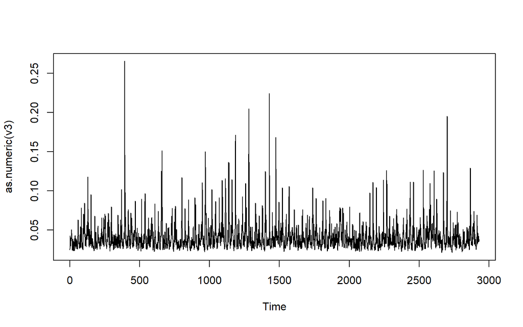

```r
v3=sigma(fit3)
ts.plot(as.numeric(v3))
```

```r
fit3_pred <- ugarchforecast(fit3, data = x, n.ahead = 10)
head(sigma(fit3_pred))
```

```
##     1978-01-06 19:00:00
## T+1          0.04627093
## T+2          0.04772776
## T+3          0.04887166
## T+4          0.04976906
## T+5          0.05047260
## T+6          0.05102387
```

```r
head(fitted(fit3_pred))
```

```
##     1978-01-06 19:00:00
## T+1           0.4682709
## T+2           0.4682709
## T+3           0.4682709
## T+4           0.4682709
## T+5           0.4682709
## T+6           0.4682709
```

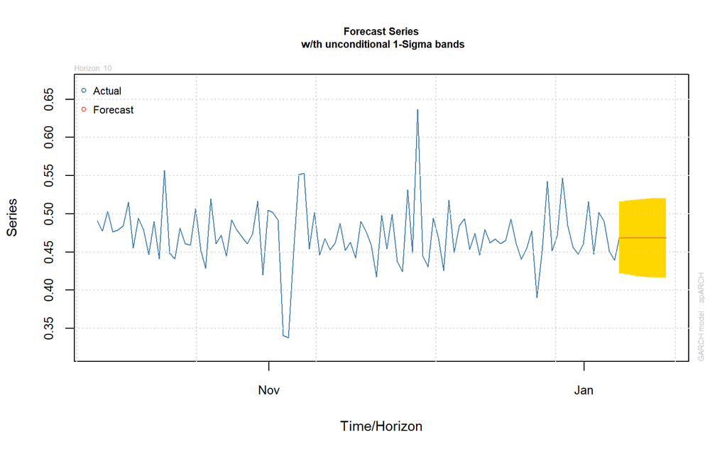

```r
plot(fit3_pred,which=1)
```

6.2. (5 points) Now use armaOrder(0,1). What are the values of AIC and BIC?

```r
spec4=ugarchspec(variance.model=list(model="apARCH"),
                 mean.model=list(armaOrder=c(0,1)))
fit4=ugarchfit(data=x,spec=spec4)
show(fit4)
```

```
##
## *---------------------------------*
## *          GARCH Model Fit        *
## *---------------------------------*
##
## Conditional Variance Dynamics
## -----------------------------------
## GARCH Model  : apARCH(1,1)
## Mean Model   : ARFIMA(0,0,1)
## Distribution : norm
##
## Optimal Parameters
## ------------------------------------
##         Estimate  Std. Error  t value Pr(>|t|)
## mu      0.467428    0.000637 733.4684 0.000000
## ma1     0.108855    0.009749  11.1654 0.000000
## omega   0.017019    0.005053   3.3684 0.000756
## alpha1  0.396772    0.029758  13.3335 0.000000
## beta1   0.459571    0.028263  16.2606 0.000000
## gamma1  0.432860    0.047995   9.0188 0.000000
## delta   0.882104    0.094217   9.3625 0.000000
##
## Robust Standard Errors:
##         Estimate  Std. Error  t value Pr(>|t|)
## mu      0.467428    0.000848 551.3288 0.000000
## ma1     0.108855    0.008213  13.2532 0.000000
## omega   0.017019    0.015057   1.1303 0.258351
## alpha1  0.396772    0.079023   5.0210 0.000001
## beta1   0.459571    0.061003   7.5336 0.000000
## gamma1  0.432860    0.097992   4.4173 0.000010
## delta   0.882104    0.287302   3.0703 0.002138
##
## LogLikelihood : 5375.752
##
## Information Criteria
## ------------------------------------
##
## Akaike       -3.6672
## Bayes        -3.6529
## Shibata      -3.6672
```

[output cut: 46 more lines]

```
## Negative Sign Bias  1.0587 0.2898
## Positive Sign Bias  0.1283 0.8979
## Joint Effect        1.1634 0.7618
##
##
## Adjusted Pearson Goodness-of-Fit Test:
## ------------------------------------
##   group statistic p-value(g-1)
## 1    20     375.9    4.393e-68
## 2    30     397.6    2.242e-66
## 3    40     422.8    6.430e-66
## 4    50     441.3    1.605e-64
##
##
## Elapsed time : 6.996545
```

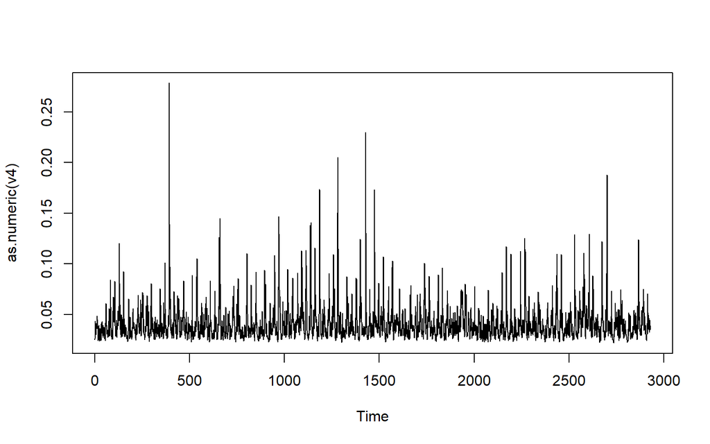

```r
v4=sigma(fit4)
ts.plot(as.numeric(v4))
```

```r
fit4_pred <- ugarchforecast(fit4, data = x, n.ahead = 10)
head(sigma(fit4_pred))
```

```
##     1978-01-06 19:00:00
## T+1          0.04533060
## T+2          0.04700035
## T+3          0.04829374
## T+4          0.04929469
## T+5          0.05006879
## T+6          0.05066715
```

```r
head(fitted(fit4_pred))
```

```
##     1978-01-06 19:00:00
## T+1           0.4645537
## T+2           0.4674283
## T+3           0.4674283
## T+4           0.4674283
## T+5           0.4674283
## T+6           0.4674283
```

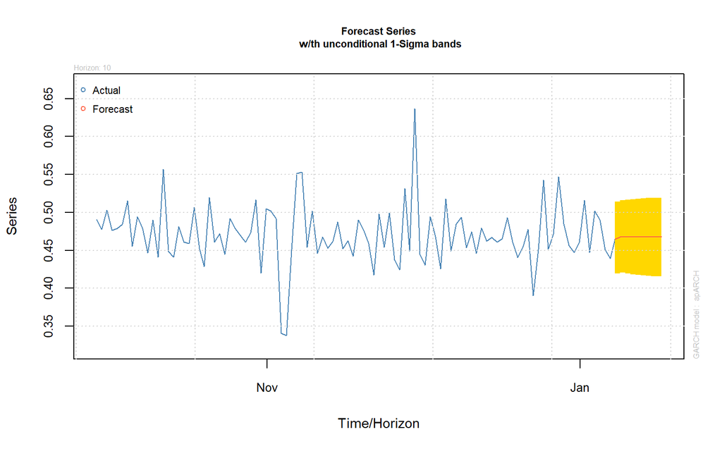

```r
plot(fit4_pred,which=1)
```

```r
fit2_pred <- ugarchforecast(fit2, data = x, n.ahead = 10)
head(sigma(fit2_pred))
```

```
##     1978-01-06 19:00:00
## T+1          0.04393086
## T+2          0.04393090
## T+3          0.04393094
## T+4          0.04393098
## T+5          0.04393102
## T+6          0.04393105
```

```r
head(fitted(fit2_pred))
```

```
##     1978-01-06 19:00:00
## T+1           0.4661424
## T+2           0.4677109
## T+3           0.4677109
## T+4           0.4677109
## T+5           0.4677109
## T+6           0.4677109
```

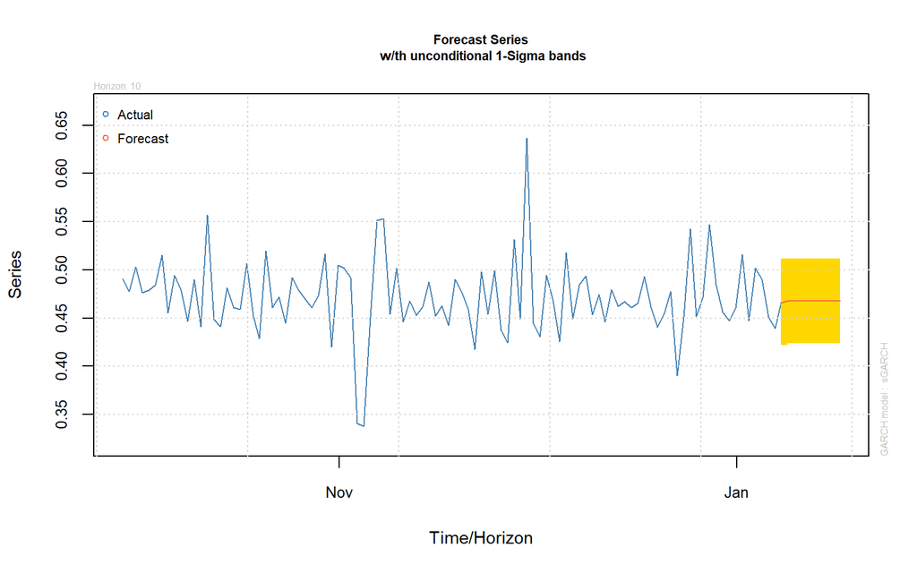

```r
plot(fit2_pred,which=1)
```

```r
#show(fit3)
```